# Taller 7: Intervalos de Confianza en R

Estadística II

M. Constanza Ayala  
maria.ayala@uv.cl  
[Agenda una reunión aquí](https://outlook.office.com/bookwithme/user/6c3f9a95bb9d4c71abbc4d73b48d50d6@uv.cl/meetingtype/HPNElmMJ_UCckWs5QZTpdw2?anonymous&ismsaljsauthenabled&ep=mLinkFromTile)

Escuela de Sociología - Universidad de Valparaíso

21 de abril, 2026

## Pasemos lista mientras descargan los materiales y dejamos todo listo ✨

📂 **Paso 1:** Abrimos nuestro proyecto con doble clic en el archivo `.Rproj`

- Si no tienen proyecto, creamos uno: `File > New Project > New Directory > New Project` — creamos carpetas: `data`, `scripts`, `figures`, `output`

💾 **Paso 2:** Movemos el archivo **“Script Taller 7 EstadisticaII.R”** a la carpeta `scripts`

📎 **Paso 3:** Movemos la base **data_elpi_selected_variables.RData** y **ELSOC_Wide_2016_2023.RData** a la carpeta `data`

> **Todos los materiales los pueden descargar en este link: [Materiales clases](https://github.com/mconstanzaa/estadistica-ii-uv-2026/)**

## Evaluación 3

Hoy tenemos nuestra **tercera evaluación individual** en R. Debes entregar lo siguiente:

- Proyecto de R (`.Rproj`).
- El script (`.R`) que contiene todos los ejercicios individuales solicitados en este taller. Debes crear un script nuevo, no utilices el script de actividades entregado en la clase.
  - En ese script, incluye un título, tu nombre, correo y fecha. Por ejemplo:

```r
# Script Ejercicio 3 Estadística II --------------------------------------------
# M. Constanza Ayala (maria.ayala@uv.cl)
# 28-04-2026
```

**Plazo de entrega:** hoy hasta las 23:59 hrs. en el Aula Virtual.

> En caso de utilizar IA, debe reportarlo en un archivo Word, indicando la herramienta y los prompts usados. El uso no reportado será calificado con nota mínima.

## Objetivos de la clase

- Comprender la lógica de los **intervalos de confianza** para medias y proporciones
- Calcular IC para medias y proporciones de forma **manual** con `summarise()`
- Calcular IC para **medias** con `DescTools::MeanCI()`
- Calcular IC para **proporciones** con `DescTools::BinomCI()`
- **Visualizar** intervalos de confianza con `ggplot2`

## ¿Qué vimos la última clase?

✅ Formulamos hipótesis nula y alternativa  
✅ Relacionamos el puntaje Z con el valor P  
✅ Realizamos pruebas de hipótesis sobre proporciones con `prop.test()`  
✅ Aplicamos `prop.test()` con datos reales de ELSOC

💡 ¡Hoy damos el paso hacia la **estimación por intervalos**!

## ¿Qué es un intervalo de confianza?

A partir de una muestra, construimos un **rango de valores plausibles** para el parámetro poblacional, con un nivel de confianza asociado.

$$IC = \text{estimación puntual} \pm \text{valor crítico} \times \text{error estándar}$$

**Componentes:**

- **Estimación puntual**: x̄ o p̂ — el centro del intervalo
- **Valor crítico**: Z o t — determina el ancho según el nivel de confianza
- **Error estándar**: mide la variabilidad muestral esperada

> Si repitiéramos el muestreo muchas veces, el X% de los intervalos construidos contendría el verdadero parámetro poblacional.

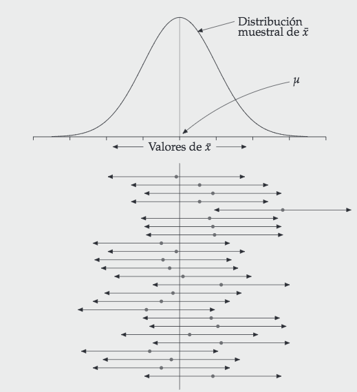

## IC para medias: fórmula

Cuando **σ es desconocida** (que es siempre el caso en la práctica) usamos la distribución **t** con gl = n − 1:

$$IC = \bar{x} \pm t_{gl,\,\alpha/2} \cdot \frac{s}{\sqrt{n}}$$

Donde:

- $\bar{x}$: media muestral
- $s$: desviación estándar muestral
- $n$: tamaño de la muestra
- $t_{gl,\,\alpha/2}$: valor crítico de la distribución t con gl = n − 1

| Nivel de confianza | α | gl | Valor crítico t (aprox.) |
| --- | --- | --- | --- |
| 90% | 0.10 | n − 1 | ≈ 1.645 (n ≥ 100) |
| 95% | 0.05 | n − 1 | ≈ 1.960 (n ≥ 100) |
| 99% | 0.01 | n − 1 | ≈ 2.576 (n ≥ 100) |

> Con n ≥ 30 la distribución muestral de x̄ es aproximadamente normal (TLC), lo que justifica usar t. Con n ≥ 100 el valor crítico t converge a Z. Con muestras pequeñas, t produce intervalos más anchos al estimar σ con s.

## Trade-offs: confianza, precisión y tamaño muestral

Tres factores determinan el ancho del IC:

| Factor | Efecto sobre el IC |
| --- | --- |
| ↑ Confianza (1−α) | IC más **ancho** → más certeza, menos precisión |
| ↑ n | IC más **estrecho** → más preciso |
| ↑ Variabilidad (s) | IC más **ancho** → menos preciso |

> No es posible aumentar simultáneamente la confianza y la precisión sin aumentar el tamaño muestral.

## Carguemos los paquetes y la base de datos

```r
options(scipen = 999)

library(tidyverse)
library(DescTools)

load("data/data_elpi_selected_variables.RData")

data %>% glimpse()
```

```
Rows: 10,867
Columns: 73
$ folio                 <dbl> 100011, 100081, 100091, 100121, 100131, 100151, …
$ wm_pb_cc              <dbl> 18, 21, 15, 13, 25, 18, 14, 11, 21, 25, 15, 20, …
$ calculation           <dbl> 0.9916786, 1.6504798, 0.3328775, -0.1063233, 2.5…
$ calculation_reliab    <dbl> 1.0467247, 1.7420946, 0.3513548, -0.1122251, 2.6…
$ wm_pb_fd              <dbl> 48, 78, 43, 33, 80, 69, 49, 37, 60, 63, 61, 43, …
$ fluency               <dbl> 0.66132153, 2.42158253, 0.36794470, -0.21880896,…
$ mfluency_reliab       <dbl> 0.66594509, 2.43851276, 0.37051715, -0.22033874,…
$ wm_pb_pa              <dbl> 33, 38, 34, 33, 41, 37, 33, 34, 32, 38, 37, 40, …
$ problems              <dbl> 0.17865414, 0.92668953, 0.32826122, 0.17865414, …
$ applied_reliab        <dbl> 0.18789990, 0.97464781, 0.34524948, 0.18789990, …
$ j2n_2012              <fct> 11, NA, 13, 11, 19, 18, 13, 11, 15, 11, 18, 13, …
$ educ2012_rec          <fct> Complete econdary education, NA, Complete econda…
$ hm1_1_2012            <dbl> NA, NA, NA, NA, NA, NA, NA, NA, NA, NA, NA, NA, …
```

[output cut: 60 more lines]

## IC para la media de `calculation`: cálculo manual

La variable `calculation` mide el puntaje en cálculo escrito (estandarizado: media = 0, sd = 1). Primero calculamos el IC aplicando directamente la fórmula con `summarise()`:

```r
data %>%
  drop_na(calculation) %>%             # eliminamos NA antes de calcular
  summarise(
    n     = n(),                        # tamaño muestral
    media = mean(calculation),          # media muestral (x̄)
    s     = sd(calculation),            # desviación estándar muestral (s)
    t     = qt(0.975, df = n - 1),      # valor crítico t para IC 95% (1 - α/2)
    lwr   = media - t * (s / sqrt(n)),  # límite inferior: x̄ - t × (s/√n)
    upr   = media + t * (s / sqrt(n))   # límite superior: x̄ + t × (s/√n)
  )
```

```
      n                      media s        t        lwr       upr
1 10674 -0.00000000000000009182169 1 1.960186 -0.0189729 0.0189729
```

- `qt(0.975, df = n - 1)` devuelve el valor crítico t que deja el 97.5% del área a su izquierda, equivalente al Z = 1.96 cuando n es grande.

## IC para medias en R: `MeanCI()`

El paquete `DescTools` incluye la función `MeanCI()`, que calcula el IC para la media usando la distribución t:

```r
library(DescTools)

MeanCI(x,               # vector numérico
       conf.level = 0.95, # nivel de confianza
       na.rm = TRUE)    # excluir NA
```

Devuelve tres valores: la media (`mean`) y los límites inferior (`lwr.ci`) y superior (`upr.ci`) del intervalo.

## IC para la media de `calculation`: con `MeanCI()`

`MeanCI()` reproduce el mismo resultado de forma directa:

```r
# IC al 95% para la media de cálculo
MeanCI(data$calculation,
       conf.level = 0.95,
       na.rm = TRUE)
```

```
                      mean                     lwr.ci
-0.00000000000000009182169 -0.01897290120900667342863
                    upr.ci
 0.01897290120900649301738
```

- Con un 95% de confianza, el intervalo [-0.019 ; 0.019] contiene el verdadero puntaje promedio poblacional en cálculo escrito.

## IC agrupado por nivel educativo del cuidador/a

Podemos calcular el IC para cada grupo usando `group_by()` y `summarise()`:

```r
data %>%
  drop_na(calculation, educ2012_rec) %>%          # eliminamos NA en ambas variables
  group_by(educ2012_rec) %>%                       # agrupamos por educación del cuidador/a
  summarise(
    n     = n(),
    media = MeanCI(calculation, conf.level = 0.95)[1],   # media
    lwr   = MeanCI(calculation, conf.level = 0.95)[2],   # límite inferior
    upr   = MeanCI(calculation, conf.level = 0.95)[3]    # límite superior
  )
```

```
# A tibble: 3 × 5
  educ2012_rec                       n   media     lwr      upr
  <fct>                          <int>   <dbl>   <dbl>    <dbl>
1 Incomplete Secondary education  1758 -0.214  -0.261  -0.168
2 Complete econdary education     6129 -0.0226 -0.0473  0.00207
3 Some higher education           1844  0.184   0.138   0.230
```

- Los grupos con mayor nivel educativo del cuidador/a tienden a mostrar puntajes promedio más altos en cálculo, con intervalos que no se superponen entre los extremos, lo que sugiere diferencias estadísticamente distinguibles entre grupos con un 95% de confianza.

## Visualización del IC por grupo

```r
data_ic <- data %>%
  drop_na(calculation, educ2012_rec) %>%          # eliminamos NA en ambas variables
  group_by(educ2012_rec) %>%                       # agrupamos por educación del cuidador/a
  summarise(
    media = MeanCI(calculation, conf.level = 0.95)[1],  # media muestral por grupo
    lwr   = MeanCI(calculation, conf.level = 0.95)[2],  # límite inferior del IC 95%
    upr   = MeanCI(calculation, conf.level = 0.95)[3]   # límite superior del IC 95%
  )

ggplot(data_ic, aes(x = educ2012_rec, y = media)) +  # educación en x, media en y
  geom_point(size = 3, color = "#9467bd") +            # punto para la media de cada grupo
  geom_errorbar(aes(ymin = lwr, ymax = upr),           # barras de error con límites del IC
                width = 0.2, color = "#9467bd") +       # ancho de las barras horizontales
  labs(title = "IC 95% para puntaje en cálculo según educación del cuidador/a",
       x = "Nivel educativo del cuidador/a",           # etiqueta eje x
       y = "Puntaje en cálculo (estandarizado)") +     # etiqueta eje y
  theme_minimal() +                                     # estilo limpio sin fondo gris
  theme(axis.text.x = element_text(angle = 25,         # rota etiquetas del eje x
                                   hjust = 1))          # alinea etiquetas rotadas a la derecha
```

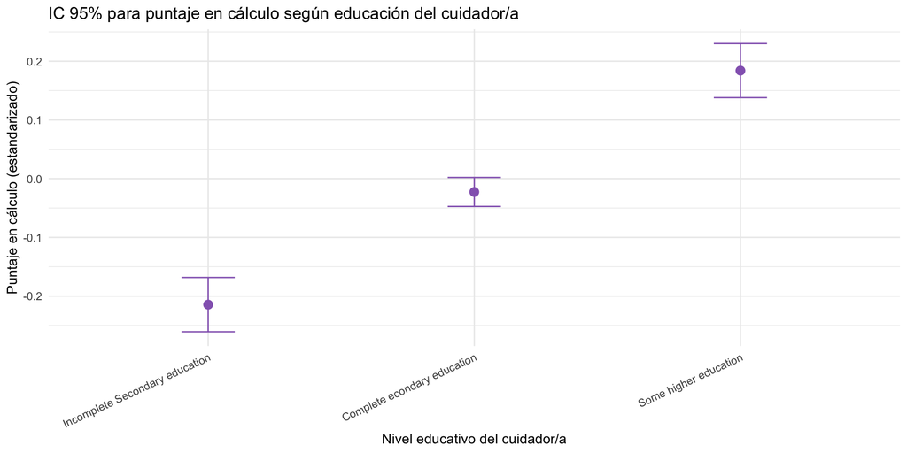

- Los intervalos que no se superponen entre grupos sugieren diferencias estadísticamente distinguibles en el puntaje de cálculo según el nivel educativo del cuidador/a.

## Actividad 1 para ejercicio

En una sección llamada `Preparación`:

1. Carga los paquetes `tidyverse` y `DescTools`, y la base `ELSOC_Wide_2016_2023.RData`.
2. Filtra la base para quedarte solo con las observaciones de la ola 2023 (`ola_w07 == 1`). Guarda el resultado como `data_elsoc_2023`.
3. Recodifica los valores `-999` y `-888` como `NA` en las variables `t02_01_w07`, `t02_02_w07` y `t02_03_w07` usando `mutate()` y `case_when()`. Verifica con `table(..., exclude = FALSE)` para al menos una variable.
4. Crea la variable `media_cohesion_barrial`: promedio de los tres ítems anteriores usando `rowMeans()` con `na.rm = TRUE`. Verifica con `summary()`.

## Actividad 2 para ejercicio

En una sección llamada `IC medias`:

1. Calcula el IC al 95% para la media de `media_cohesion_barrial` con `MeanCI()`. Interpreta el resultado como comentario (`#`) en el script.
2. Calcula el IC al 95% agrupando por `m0_sexo_w07` usando `group_by()` y `summarise()`. Antes de calcular, recodifica `m0_sexo_w07` como factor con etiquetas (`"Hombre"`, `"Mujer"`).
3. Crea un gráfico de puntos con barras de error (`geom_errorbar()`) para visualizar los IC por sexo. Incluye título y etiquetas de ejes.

## IC para proporciones: fórmula

Para proporciones **siempre se usa Z** (no t):

$$IC = \hat{p} \pm Z_{\alpha/2} \cdot \sqrt{\frac{\hat{p}(1-\hat{p})}{n}}$$

Donde:

- $\hat{p}$: proporción muestral
- $n$: tamaño de la muestra
- $Z_{\alpha/2}$: valor crítico de la distribución normal estándar

**Condición de aplicación:** np̂ ≥ 5 y n(1 − p̂) ≥ 5

> El error estándar de una proporción depende del propio valor de p̂: es máximo cuando p̂ = 0.50 y se reduce a medida que p̂ se aleja de 0.50.

## Identificación con pueblo originario — cálculo manual

Usamos la variable `indig_nino` (pertenencia a pueblo originario, dicotómica). Primero aplicamos la fórmula directamente:

```r
table(data$indig_nino, exclude = FALSE)
```

```
  No Indig Indigenous
      9399       1468
```

```r
data %>%
  drop_na(indig_nino) %>%                           # eliminamos NA antes de calcular
  summarise(
    n       = n(),                                   # tamaño muestral
    n_indig = sum(indig_nino == "Indigenous"),       # casos pertenecientes a pueblo originario
    p_hat   = n_indig / n,                           # proporción muestral (p̂)
    se      = sqrt(p_hat * (1 - p_hat) / n),         # error estándar
    lwr     = p_hat - 1.96 * se,                     # límite inferior (Z = 1.96)
    upr     = p_hat + 1.96 * se                      # límite superior
  )
```

```
      n n_indig     p_hat          se       lwr       upr
1 10867    1468 0.1350879 0.003278984 0.1286611 0.1415147
```

Con un 95% de confianza, el intervalo [12.9% ; 14.2%] contiene la verdadera proporción poblacional de niños/as pertenecientes a un pueblo originario en el contexto escolar chileno estudiado.

## IC para proporciones en R: `BinomCI()`

`DescTools` incluye `BinomCI()` para calcular el IC de una proporción:

```r
BinomCI(x,                    # número de casos que cumplen la condición
        n,                    # total de casos
        conf.level = 0.95,    # nivel de confianza
        method = "wald")      # método de Wald: fórmula Z estándar
```

El método `"wald"` corresponde exactamente a la fórmula:

$$IC = \hat{p} \pm Z_{\alpha/2} \cdot \sqrt{\frac{\hat{p}(1-\hat{p})}{n}}$$

> Devuelve tres valores: la proporción estimada (`est`) y los límites inferior (`lwr.ci`) y superior (`upr.ci`).

## Identificación con pueblo originario — con `BinomCI()`

`BinomCI()` reproduce el mismo resultado usando el método de Wald:

```r
n_total <- sum(!is.na(data$indig_nino))
n_indig <- sum(data$indig_nino == "Indigenous", na.rm = TRUE)

BinomCI(x = n_indig,
        n = n_total,
        conf.level = 0.95,
        method = "wald")
```

```
           est    lwr.ci    upr.ci
[1,] 0.1350879 0.1286612 0.1415146
```

-️ La proporción estimada de niños/as pertenecientes a un pueblo originario en la muestra, junto a su intervalo de confianza al 95%, refleja la representación de esta población en el contexto escolar chileno estudiado.

## IC de proporción agrupado por sexo

Podemos calcular el IC para cada grupo con `group_by()` y `summarise()`:

```r
data %>%
  drop_na(indig_nino, sex) %>%                                                      # eliminamos NA en ambas variables
  group_by(sex) %>%                                                                  # agrupamos por sexo
  summarise(
    n       = n(),                                                                   # tamaño muestral por grupo
    n_indig = sum(indig_nino == "Indigenous"),                                       # casos por grupo
    prop    = n_indig / n,                                                           # proporción por grupo (p̂)
    lwr     = BinomCI(n_indig, n, conf.level = 0.95, method = "wald")[, "lwr.ci"],  # límite inferior IC 95%
    upr     = BinomCI(n_indig, n, conf.level = 0.95, method = "wald")[, "upr.ci"]   # límite superior IC 95%
  )
```

```
# A tibble: 2 × 6
  sex        n n_indig  prop   lwr   upr
  <fct>  <int>   <int> <dbl> <dbl> <dbl>
1 Male    5525     727 0.132 0.123 0.140
2 Female  5342     741 0.139 0.129 0.148
```

- La proporción de niños/as pertenecientes a pueblo originario es similar entre niñas y niños, con intervalos que se superponen ampliamente, lo que indica que no existe una diferencia estadísticamente distinguible por sexo en esta muestra.

## Visualización del IC de proporción

```r
data_ic_prop <- data %>%
  drop_na(indig_nino, sex) %>%                                                      # eliminamos NA en ambas variables
  group_by(sex) %>%                                                                  # agrupamos por sexo
  summarise(
    n       = n(),                                                                   # tamaño muestral por grupo
    n_indig = sum(indig_nino == "Indigenous"),                                       # casos por grupo
    prop    = n_indig / n,                                                           # proporción por grupo (p̂)
    lwr     = BinomCI(n_indig, n, conf.level = 0.95, method = "wald")[, "lwr.ci"],  # límite inferior IC 95%
    upr     = BinomCI(n_indig, n, conf.level = 0.95, method = "wald")[, "upr.ci"]   # límite superior IC 95%
  )

ggplot(data_ic_prop, aes(x = sex, y = prop)) +  # sexo en x, proporción en y
  geom_point(size = 3, color = "#9467bd") +       # punto para la proporción de cada grupo
  geom_errorbar(aes(ymin = lwr, ymax = upr),      # barras de error con límites del IC
                width = 0.15, color = "#9467bd") + # ancho de las barras horizontales
  scale_y_continuous(labels = scales::percent_format(accuracy = 1)) + # formato porcentaje
  labs(title = "IC 95% para proporción de niños/as de pueblo originario según sexo",
       x = "Sexo",                                # etiqueta eje x
       y = "Proporción estimada") +               # etiqueta eje y
  theme_minimal()                                  # estilo limpio sin fondo gris
```

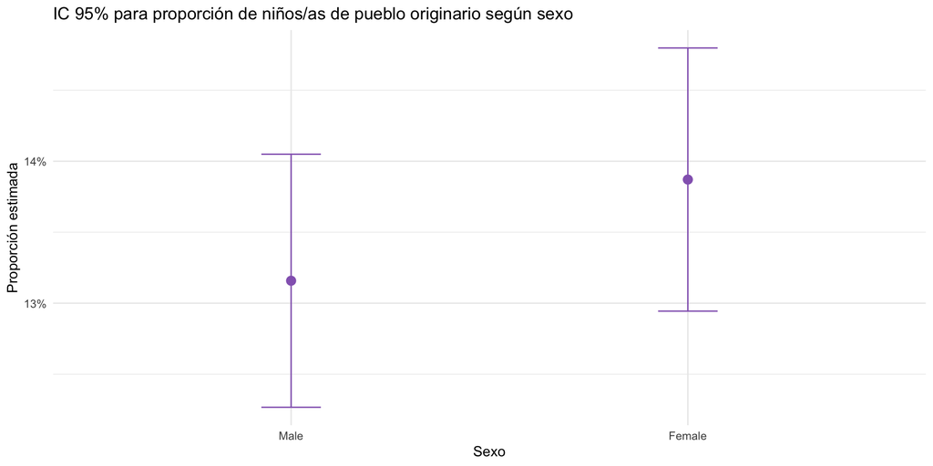

## Actividad 3 para ejercicio

En una sección llamada `IC proporciones`:

La variable `c02_w07` mide confianza social generalizada: `1` = “casi siempre se puede confiar en las personas”, `2` = “hay que tener cuidado”, `3` = “depende”.

1. Recodifica los valores `-999` y `-888` como `NA` en `c02_w07`, y luego crea la variable dicotómica `confia_personas`: `1` si el valor es `1`, `0` si el valor es `2` o `3`. Usa `mutate()` y `case_when()`. Verifica con `table(..., exclude = FALSE)`.
2. Calcula el IC al 95% para la proporción de personas que confían en los demás con `BinomCI()`. Interpreta el resultado como comentario (`#`) en el script.

## ❓ Preguntas y aclaraciones

💬 **¿Dudas sobre lo visto hoy?**

- Tómense un momento para reflexionar y compartir preguntas sobre el contenido.
- Espacio para responder inquietudes y aclarar conceptos clave.

## Resumen clase de hoy

✅ Comprendimos la lógica de los intervalos de confianza para medias y proporciones

✅ Calculamos IC para medias con `DescTools::MeanCI()` (distribución t)

✅ Calculamos IC para proporciones con `DescTools::BinomCI()` (método de Wald)

✅ Visualizamos intervalos con `geom_errorbar()` en `ggplot2`

✅ Aplicamos ambos tipos de IC con datos reales de ELPI y ELSOC

## 📆 Próxima sesión

- Muestreo en R

## 📚 Sugerencias lecturas para reforzar R

- Wickham & Grolemund. R for Data Science (acceso en línea biblioteca, en español: https://es.r4ds.hadley.nz/)
- [AnalizaR Datos Políticos](https://arcruz0.github.io/libroadp/index.html)
- [YaRrr! The Pirate’s Guide to R](https://bookdown.org/ndphillips/YaRrr/)